# EXAMEN MÓDULO 1 - DATA SCIENCE Y BIG DATA. LA NUEVA REALIDAD

Alejandro J. Gómez Ortiz

2026-03-05

# PREPROCESADO DE DATOS

La columna `Diagnosis`(binario) indica si el paciente ha sido diagnosticado con Parkinson (1) o no (0).

Se solicita:

1. Análisis descriptivo y gráfico de las variables (univariante y bivariante)
2. Revisión de posibles valores atípicos siguiendo tanto métodos univariantes como multivariantes
3. Imputación de datos ausentes en las variables correspondientes
4. Equilibrado de la muestra sobre la variable `Diagnosis`: reducción de la clase mayoritaria hasta igualar el número de instancias de la clase minoritaria

```r
#LIBRERIAS

library(arrow)
library(data.table)
library(tidyverse)
library(skimr)
library(formattable)
library(corrplot)
library(gridExtra)
library(solitude)

# reproducibilidad
set.seed(123)

source("funciones.R")

df <- read_parquet("parkinsons_disease_data.parquet")
```

Se comprueba que los datos se han cargado correctamente:

```r
formattable(head(df))
```

| PatientID | Age | Gender | Ethnicity | EducationLevel | BMI | Smoking | AlcoholConsumption | PhysicalActivity | DietQuality | SleepQuality | FamilyHistoryParkinsons | TraumaticBrainInjury | Hypertension | Diabetes | Depression | Stroke | SystolicBP | DiastolicBP | CholesterolTotal | CholesterolLDL | CholesterolHDL | CholesterolTriglycerides | UPDRS | MoCA | FunctionalAssessment | Tremor | Rigidity | Bradykinesia | PosturalInstability | … |
| --- | --- | --- | --- | --- | --- | --- | --- | --- | --- | --- | --- | --- | --- | --- | --- | --- | --- | --- | --- | --- | --- | --- | --- | --- | --- | --- | --- | --- | --- | --- |
| 3058 | 85 | 0 | 3 | 1 | 19.61988 | 0 | 5.108241 | 1.3806599 | 3.893969 | 9.283194 | 0 | 0 | 0 | 0 | 0 | 0 | 129 | 60 | 222.8423 | 148.12562 | 37.86778 | 337.3071 | 6.458713 | 29.181289 | 1.572427 | 1 | 0 | 0 | 0 | … |
| 3059 | 75 | 0 | 0 | 2 | 16.24734 | 1 | 6.027648 | 8.4098041 | 8.513428 | 5.602470 | 0 | 0 | 0 | 0 | 0 | 0 | 163 | 76 | 210.5011 | 153.75646 | 77.22812 | 264.6355 | 37.306703 | 12.332639 | 4.787551 | 0 | 1 | 0 | 1 | … |
| 3060 | 70 | 1 | 0 | 0 | 15.36824 | 0 | 2.242135 | 0.2132746 | 6.498805 | 9.929824 | 0 | 0 | 0 | 1 | 0 | 0 | 113 | 93 | 287.3880 | 118.70260 | 85.58830 | 395.6626 | 67.838170 | 29.927783 | 2.130686 | 1 | 0 | 0 | 0 | … |
| 3061 | 52 | 0 | 0 | 0 | 15.45456 | 0 | 5.997788 | 1.3750452 | 6.715033 | 4.196189 | 0 | 0 | 0 | 0 | 0 | 0 | 146 | 78 | 280.3395 | 136.29919 | 51.86963 | 362.1897 | 52.964696 | 21.304268 | 3.391288 | 1 | 1 | 1 | 0 | … |
| 3062 | 87 | 0 | 0 | 1 | 18.61604 | 0 | 9.775243 | 1.1886071 | 4.657572 | 9.363925 | 0 | 0 | 0 | 0 | 0 | 0 | 115 | 94 | 284.0142 | 108.44945 | 25.06942 | 149.9566 | 21.804880 | 8.336364 | 3.200969 | 0 | 0 | 0 | 1 | … |
| 3063 | 68 | 1 | 2 | 1 | 39.42331 | 1 | 13.596889 | 7.7967040 | 7.070239 | 7.737549 | 0 | 0 | 0 | 0 | 0 | 0 | 151 | 90 | 290.1331 | 91.75022 | 54.48892 | 253.7973 | 101.912536 | 27.370580 | 6.824779 | 0 | 0 | 0 | 0 | … |

Eliminamos la variable DoctorInCharge ya que no forma parte de las variables objeto de estudio (segun el enunciado) y volvemos a comprobar los datos:

```r
df <- df %>% select(-DoctorInCharge)
formattable(head(df))
```

| PatientID | Age | Gender | Ethnicity | EducationLevel | BMI | Smoking | AlcoholConsumption | PhysicalActivity | DietQuality | SleepQuality | FamilyHistoryParkinsons | TraumaticBrainInjury | Hypertension | Diabetes | Depression | Stroke | SystolicBP | DiastolicBP | CholesterolTotal | CholesterolLDL | CholesterolHDL | CholesterolTriglycerides | UPDRS | MoCA | FunctionalAssessment | Tremor | Rigidity | Bradykinesia | PosturalInstability | … |
| --- | --- | --- | --- | --- | --- | --- | --- | --- | --- | --- | --- | --- | --- | --- | --- | --- | --- | --- | --- | --- | --- | --- | --- | --- | --- | --- | --- | --- | --- | --- |
| 3058 | 85 | 0 | 3 | 1 | 19.61988 | 0 | 5.108241 | 1.3806599 | 3.893969 | 9.283194 | 0 | 0 | 0 | 0 | 0 | 0 | 129 | 60 | 222.8423 | 148.12562 | 37.86778 | 337.3071 | 6.458713 | 29.181289 | 1.572427 | 1 | 0 | 0 | 0 | … |
| 3059 | 75 | 0 | 0 | 2 | 16.24734 | 1 | 6.027648 | 8.4098041 | 8.513428 | 5.602470 | 0 | 0 | 0 | 0 | 0 | 0 | 163 | 76 | 210.5011 | 153.75646 | 77.22812 | 264.6355 | 37.306703 | 12.332639 | 4.787551 | 0 | 1 | 0 | 1 | … |
| 3060 | 70 | 1 | 0 | 0 | 15.36824 | 0 | 2.242135 | 0.2132746 | 6.498805 | 9.929824 | 0 | 0 | 0 | 1 | 0 | 0 | 113 | 93 | 287.3880 | 118.70260 | 85.58830 | 395.6626 | 67.838170 | 29.927783 | 2.130686 | 1 | 0 | 0 | 0 | … |
| 3061 | 52 | 0 | 0 | 0 | 15.45456 | 0 | 5.997788 | 1.3750452 | 6.715033 | 4.196189 | 0 | 0 | 0 | 0 | 0 | 0 | 146 | 78 | 280.3395 | 136.29919 | 51.86963 | 362.1897 | 52.964696 | 21.304268 | 3.391288 | 1 | 1 | 1 | 0 | … |
| 3062 | 87 | 0 | 0 | 1 | 18.61604 | 0 | 9.775243 | 1.1886071 | 4.657572 | 9.363925 | 0 | 0 | 0 | 0 | 0 | 0 | 115 | 94 | 284.0142 | 108.44945 | 25.06942 | 149.9566 | 21.804880 | 8.336364 | 3.200969 | 0 | 0 | 0 | 1 | … |
| 3063 | 68 | 1 | 2 | 1 | 39.42331 | 1 | 13.596889 | 7.7967040 | 7.070239 | 7.737549 | 0 | 0 | 0 | 0 | 0 | 0 | 151 | 90 | 290.1331 | 91.75022 | 54.48892 | 253.7973 | 101.912536 | 27.370580 | 6.824779 | 0 | 0 | 0 | 0 | … |

El dataset contiene variables de diferente naturaleza: variables continuas como `Age`, `BMI`, `SystolicBP` o `MoCA`, y variables binarias codificadas como 0/1 que representan presencia o ausencia de una condición. La variable objetivo `Diagnosis` también es binaria.

Se convierte `Diagnosis` a factor para que sea tratada como variable categórica en los gráficos y agrupaciones:

```r
df$Diagnosis <- as.factor(df$Diagnosis)

sapply(df, class)
```

```
##                PatientID                      Age                   Gender
##                "integer"                "integer"                "integer"
##                Ethnicity           EducationLevel                      BMI
##                "integer"                "integer"                "numeric"
##                  Smoking       AlcoholConsumption         PhysicalActivity
##                "integer"                "numeric"                "numeric"
##              DietQuality             SleepQuality  FamilyHistoryParkinsons
##                "numeric"                "numeric"                "integer"
##     TraumaticBrainInjury             Hypertension                 Diabetes
##                "integer"                "integer"                "integer"
##               Depression                   Stroke               SystolicBP
##                "integer"                "integer"                "integer"
##              DiastolicBP         CholesterolTotal           CholesterolLDL
##                "integer"                "numeric"                "numeric"
##           CholesterolHDL CholesterolTriglycerides                    UPDRS
##                "numeric"                "numeric"                "numeric"
##                     MoCA     FunctionalAssessment                   Tremor
##                "numeric"                "numeric"                "integer"
##                 Rigidity             Bradykinesia      PosturalInstability
##                "integer"                "integer"                "integer"
##           SpeechProblems           SleepDisorders             Constipation
##                "integer"                "integer"                "integer"
##                Diagnosis
##                 "factor"
```

De este modo se garantiza que las variables numéricas son numéricas y que la variable objetivo es factor.

# 1. Análisis descriptivo y gráfico de las variables (univariante y bivariante)

## 1.1 Tipado de variables y valores nulos

Se realiza un primer análisis descriptivo completo del dataset para conocer su estructura, el tipado de las variables y la presencia de valores nulos:

```r
desc_df <- skim(df)

var_type_missing_df <- desc_df %>%
  mutate(n_missing_perc = 100 * round(1 - complete_rate, 3)) %>%
  select(skim_type, skim_variable, n_missing, n_missing_perc) %>%
  arrange(skim_type, n_missing)

formattable(var_type_missing_df)
```

| skim_type | skim_variable | n_missing | n_missing_perc |
| --- | --- | --- | --- |
| factor | Diagnosis | 0 | 0 |
| numeric | PatientID | 0 | 0 |
| numeric | Age | 0 | 0 |
| numeric | Gender | 0 | 0 |
| numeric | Ethnicity | 0 | 0 |
| numeric | EducationLevel | 0 | 0 |
| numeric | BMI | 0 | 0 |
| numeric | Smoking | 0 | 0 |
| numeric | AlcoholConsumption | 0 | 0 |
| numeric | PhysicalActivity | 0 | 0 |
| numeric | DietQuality | 0 | 0 |
| numeric | SleepQuality | 0 | 0 |
| numeric | FamilyHistoryParkinsons | 0 | 0 |
| numeric | TraumaticBrainInjury | 0 | 0 |
| numeric | Hypertension | 0 | 0 |
| numeric | Diabetes | 0 | 0 |
| numeric | Depression | 0 | 0 |
| numeric | Stroke | 0 | 0 |
| numeric | SystolicBP | 0 | 0 |
| numeric | DiastolicBP | 0 | 0 |
| numeric | CholesterolTotal | 0 | 0 |
| numeric | CholesterolLDL | 0 | 0 |
| numeric | CholesterolHDL | 0 | 0 |
| numeric | CholesterolTriglycerides | 0 | 0 |
| numeric | UPDRS | 0 | 0 |
| numeric | MoCA | 0 | 0 |
| numeric | FunctionalAssessment | 0 | 0 |
| numeric | Tremor | 0 | 0 |
| numeric | Rigidity | 0 | 0 |
| numeric | Bradykinesia | 0 | 0 |
| numeric | PosturalInstability | 0 | 0 |
| numeric | SpeechProblems | 0 | 0 |
| numeric | SleepDisorders | 0 | 0 |
| numeric | Constipation | 0 | 0 |

Se observa que no existen valores nulos en ninguna de las variables del dataset. Lo confirmo calculando el porcentaje total:

```r
# Porcentaje total de valores nulos
sum(var_type_missing_df$n_missing_perc)
```

```
## [1] 0
```

Al ser este valor 0, no será necesario aplicar ninguna técnica de imputación ni excluir variables por superar el umbral del 15% de nulos.

## 1.2 Análisis univariante y bivariante

### 1.2.1 Variables numéricas continuas

Se separan las variables según su naturaleza antes de analizarlas. Las variables binarias codificadas como 0/1 se tratarán por separado como categóricas, ya que aplicarles histogramas o boxplots no aportaría información relevante:

```r
vars_numericas <- c(
  "Age", "BMI", "AlcoholConsumption", "PhysicalActivity",
  "DietQuality", "SleepQuality", "SystolicBP", "DiastolicBP",
  "CholesterolTotal", "CholesterolLDL", "CholesterolHDL",
  "CholesterolTriglycerides", "MoCA", "FunctionalAssessment"
)

vars_categoricas <- c(
  "Gender", "Ethnicity", "EducationLevel", "Smoking",
  "FamilyHistoryParkinsons", "TraumaticBrainInjury", "Hypertension",
  "Diabetes", "Depression", "Stroke", "Tremor", "Rigidity",
  "Bradykinesia", "PosturalInstability", "SpeechProblems",
  "SleepDisorders", "Constipation"
)
```

Estadísticos descriptivos de las variables numéricas:

```r
desc_numeric_var_df <- desc_df %>%
  filter(skim_type == "numeric") %>%
  filter(skim_variable %in% vars_numericas) %>%
  select(skim_variable,
         numeric.mean, numeric.sd,
         numeric.p0, numeric.p25, numeric.p50, numeric.p75, numeric.p100)

formattable(desc_numeric_var_df)
```

| skim_variable | numeric.mean | numeric.sd | numeric.p0 | numeric.p25 | numeric.p50 | numeric.p75 | numeric.p100 |
| --- | --- | --- | --- | --- | --- | --- | --- |
| Age | 69.601900 | 11.594511 | 5.000000e+01 | 60.000000 | 70.000000 | 80.000000 | 89.000000 |
| BMI | 27.209493 | 7.208099 | 1.500833e+01 | 20.782176 | 27.184571 | 33.462452 | 39.999887 |
| AlcoholConsumption | 10.040413 | 5.687014 | 2.227955e-03 | 5.150278 | 10.070337 | 14.829565 | 19.988866 |
| PhysicalActivity | 5.016674 | 2.890919 | 4.156688e-03 | 2.455703 | 5.031550 | 7.512795 | 9.995255 |
| DietQuality | 4.912901 | 2.872115 | 1.053818e-05 | 2.478503 | 4.825187 | 7.381487 | 9.995864 |
| SleepQuality | 6.996639 | 1.753065 | 4.000497e+00 | 5.488864 | 6.929819 | 8.558719 | 9.999821 |
| SystolicBP | 133.719715 | 26.502355 | 9.000000e+01 | 110.000000 | 133.000000 | 157.000000 | 179.000000 |
| DiastolicBP | 90.249881 | 17.061488 | 6.000000e+01 | 75.000000 | 91.000000 | 105.000000 | 119.000000 |
| CholesterolTotal | 226.860840 | 43.589406 | 1.500627e+02 | 189.385178 | 228.528256 | 264.608100 | 299.963074 |
| CholesterolLDL | 126.147858 | 43.407036 | 5.002283e+01 | 88.841960 | 126.884570 | 163.912782 | 199.985981 |
| CholesterolHDL | 59.670352 | 23.370920 | 2.002798e+01 | 39.538643 | 59.343357 | 79.366628 | 99.982265 |
| CholesterolTriglycerides | 222.940500 | 101.895822 | 5.011360e+01 | 132.520174 | 222.802452 | 311.699109 | 399.975022 |
| MoCA | 15.094314 | 8.643014 | 2.119121e-02 | 7.517160 | 14.963574 | 22.608362 | 29.970107 |
| FunctionalAssessment | 4.989694 | 2.933877 | 1.505123e-03 | 2.415890 | 4.983227 | 7.484220 | 9.992697 |

A continuación se representan los histogramas univariantes con curva de normalidad superpuesta para evaluar la distribución de cada variable:

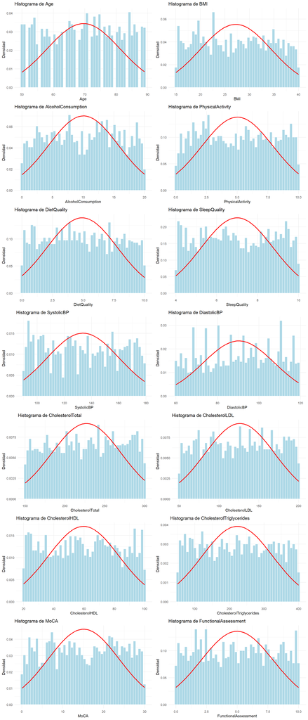

```r
plots_hist <- lapply(vars_numericas, function(var) histogram_plot(df, var))

grid.arrange(grobs = plots_hist, ncol = 2)
```

Se representan los histogramas bivariantes segmentados por `Diagnosis` para detectar diferencias entre grupos:

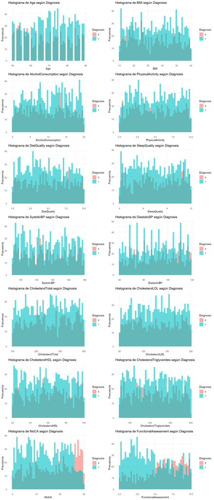

```r
plots_hist_target <- lapply(vars_numericas, function(var) {
  histogram_var_target_plot(df, var, "Diagnosis")
})

grid.arrange(grobs = plots_hist_target, ncol = 2)
```

Se puede observar que variables como `MoCA` y `FunctionalAssessment` presentan distribuciones claramente diferenciadas entre los pacientes con y sin diagnóstico positivo: los pacientes diagnosticados con Parkinson tienden a obtener puntuaciones más bajas en estas evaluaciones. El resto de variables numéricas no muestra diferencias evidentes entre grupos.

Se completa el análisis con los gráficos de cajas y bigotes, que permiten visualizar mejor la distribución y los posibles valores extremos:

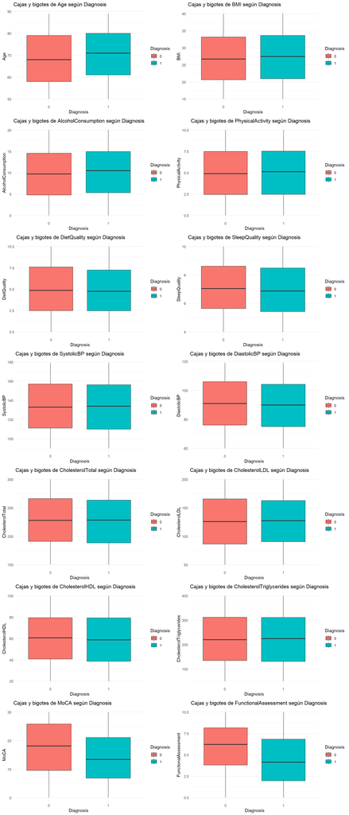

```r
plots_box <- lapply(vars_numericas, function(var) {
  boxplot_var_target_plot(df, var, "Diagnosis")
})

grid.arrange(grobs = plots_box, ncol = 2)
```

### 1.2.2 Gráficos de dispersión entre variables numéricas

Se analiza la relación entre pares de variables clínicas relevantes según el diagnóstico para detectar posibles patrones o agrupaciones:

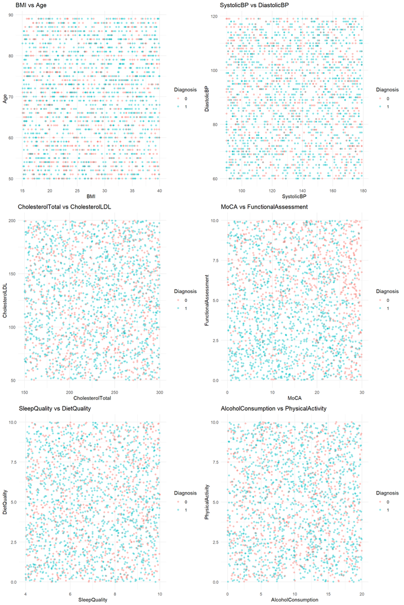

```r
pares_scatter <- list(
  c("BMI", "Age"),
  c("SystolicBP", "DiastolicBP"),
  c("CholesterolTotal", "CholesterolLDL"),
  c("MoCA", "FunctionalAssessment"),
  c("SleepQuality", "DietQuality"),
  c("AlcoholConsumption", "PhysicalActivity")
)

plots_scatter <- lapply(pares_scatter, function(par) {
  scatter_plot(df, par[1], par[2], "Diagnosis")
})

grid.arrange(grobs = plots_scatter, ncol = 2)
```

De los gráficos de dispersión hay que destacar que la relación entre `MoCA` y `FunctionalAssessment` es la que muestra una separación más clara entre pacientes con y sin Parkinson, con los casos positivos concentrándose en valores bajos de ambas variables. El resto de pares no muestra patrones de separación evidentes, lo que es coherente con las bajas correlaciones que se observarán en la matriz de correlaciones.

### 1.2.3 Variables categóricas binarias

Para las variables codificadas como binarias, se analiza su distribución y su relación con `Diagnosis` mediante gráficos de barras apiladas proporcionales, que permiten ver qué proporción de cada categoría corresponde a cada grupo diagnóstico:

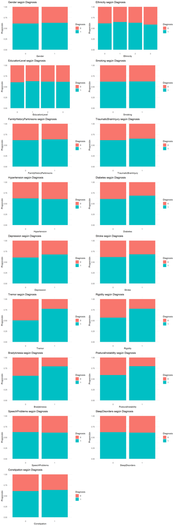

```r
plots_bar <- lapply(vars_categoricas, function(var) {
  barplot_categorica_target_plot(df, var, "Diagnosis")
})

grid.arrange(grobs = plots_bar, ncol = 2)
```

De los gráficos de barras apiladas se observa que las variables sintomáticas `Tremor`, `Rigidity`, `Bradykinesia` y `PosturalInstability` presentan proporciones claramente distintas entre los grupos: la presencia de estos síntomas está mucho más asociada al diagnóstico positivo que su ausencia. Variables como `Gender`, `Smoking` o `Hypertension` muestran proporciones similares en ambos grupos, lo que sugiere que tienen menor poder discriminante.

### 1.3 Matriz de correlaciones

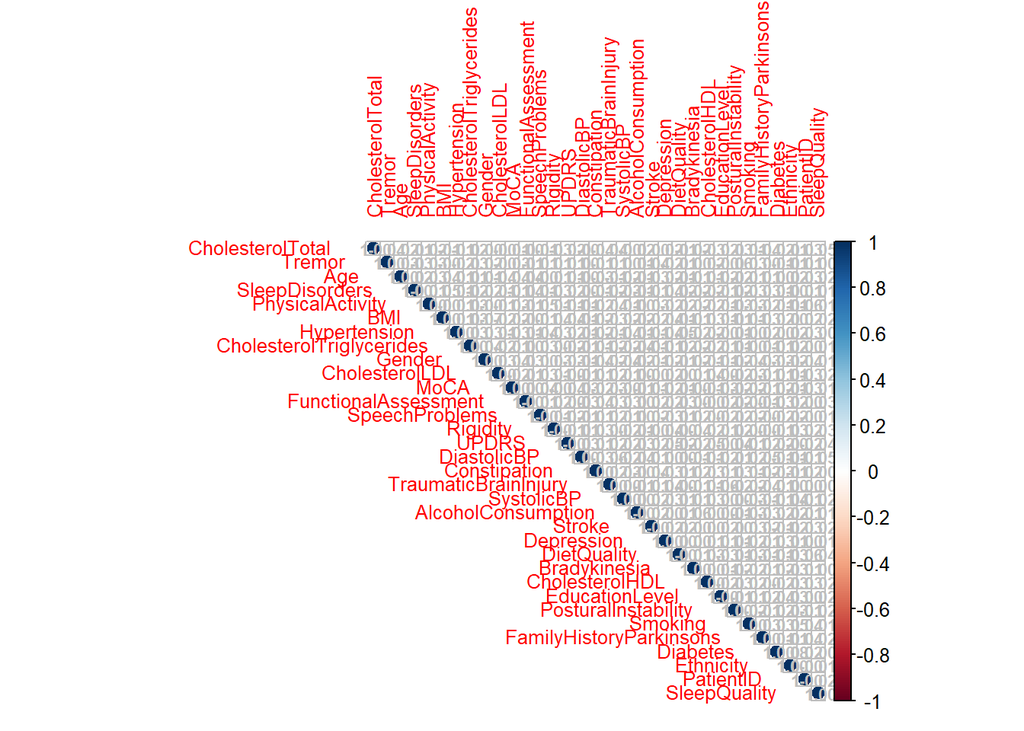

```r
df_num <- select_if(df, is.numeric)

correlacion_pearson_df <- cor(df_num, use = "pairwise.complete.obs")

corrplot(correlacion_pearson_df,
         tl.cex    = 0.8,
         tl.offset = 1.2,
         type      = "upper",
         method    = "circle",
         addCoef.col = "grey",
         order     = "AOE",
         number.cex = 0.7)
```

Dado que las correlaciones son en general bajas, en caso de existir valores nulos habría optado por una **imputación estratificada por la mediana** según la variable objetivo `Diagnosis`. Este enfoque es preferible a la media porque la mediana es menos sensible a valores extremos y respeta mejor la distribución de cada grupo diagnóstico.

A continuación se amplía el análisis incluyendo también la variable `Diagnosis` convertida a numérico, filtrando las correlaciones por significatividad estadística para reducir el ruido visual:

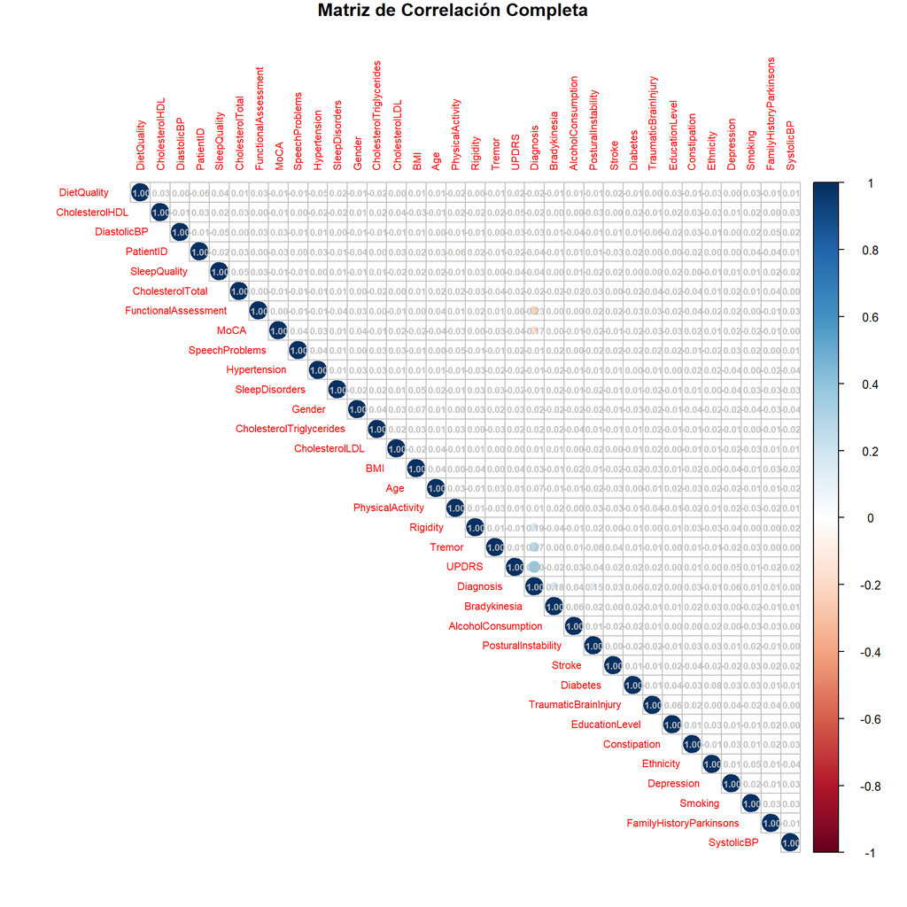

```r
# Convierto todo a numérico (incluyendo factores binarios)
df_num <- df %>%
  mutate(Diagnosis = as.numeric(as.character(Diagnosis))) %>%
  select_if(is.numeric)

# Calculo la correlacion de Pearson
correlacion_pearson_df <- cor(df_num, use = "pairwise.complete.obs")

# Dibujo la matriz COMPLETA
corrplot(correlacion_pearson_df,
         tl.cex    = 0.7,
         tl.offset = 1.2,
         type      = "upper",
         method    = "circle",
         addCoef.col = "grey",
         order     = "AOE",
         number.cex = 0.6,
         title     = "Matriz de Correlación Completa",
         mar       = c(0,0,1,0))
```

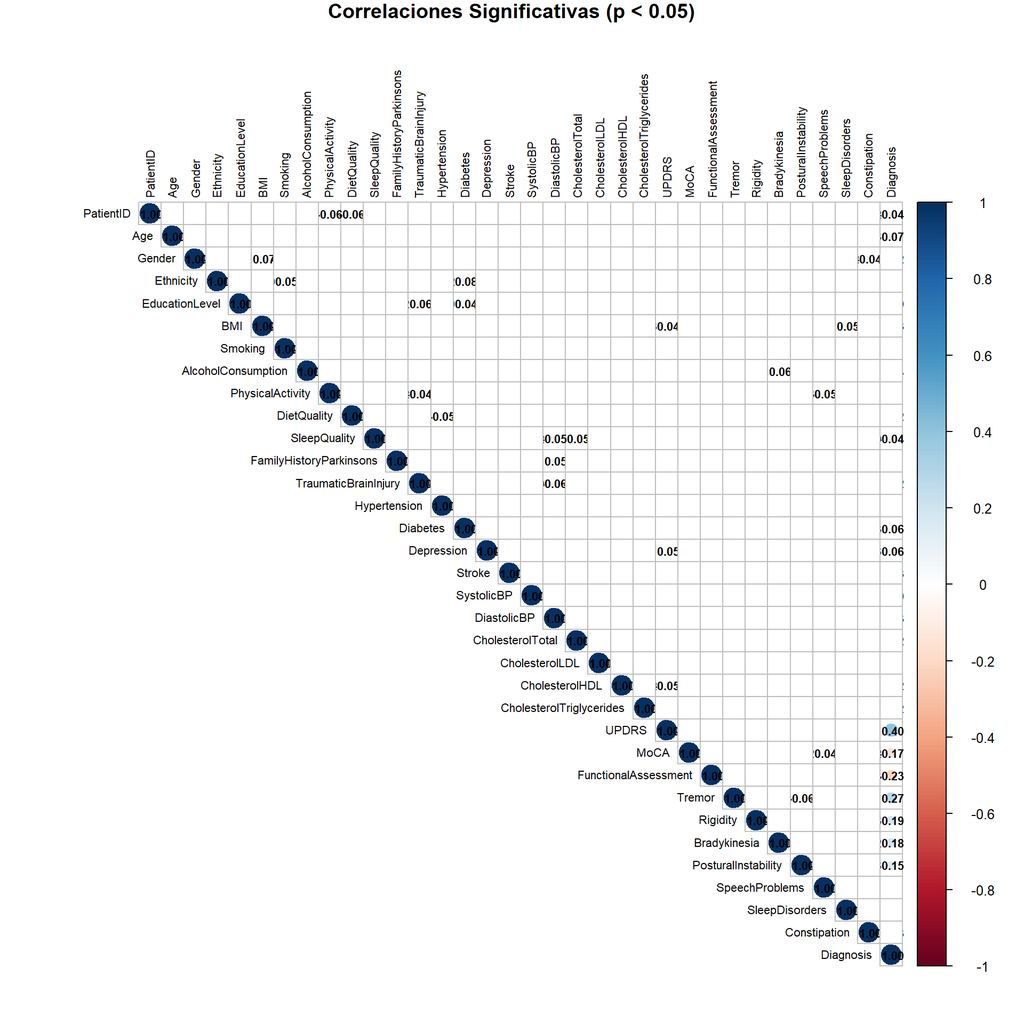

```r
# Calculo p-valores para filtrar correlaciones no significativas
p_mat <- cor.mtest(df_num, conf.level = 0.95)

# Represento solo correlaciones significativas respecto a Diagnosis y el resto de variables
corrplot(correlacion_pearson_df,
         p.mat       = p_mat$p,
         sig.level   = 0.05,
         insig       = "blank",
         type        = "upper",
         method      = "circle",
         tl.cex      = 0.7,
         tl.col      = "black",
         addCoef.col = "black",
         number.cex  = 0.7,
         title       = "Correlaciones Significativas (p < 0.05)",
         mar         = c(0,0,1,0))
```

# ¿Cuáles son los factores más influyentes en el diagnóstico de la enfermedad de Parkinson?

Observando la matriz de correlaciones significativas (p < 0.05) respecto a la variable objetivo `Diagnosis`, se identifican los siguientes factores como los más influyentes:

## Factores con correlación negativa (el riesgo aumenta cuando su valor disminuye)

`Diagnosis` está negativamente correlacionada de forma destacada con las métricas de evaluación continua: `FunctionalAssessment` (-0.23) y `MoCA` (-0.17). A medida que los pacientes obtienen puntuaciones más bajas en estas pruebas —lo que refleja un mayor deterioro en su capacidad funcional y cognitiva— la probabilidad de obtener un diagnóstico positivo es mayor. Esto tiene una interpretación clínica clara: el deterioro cognitivo y funcional es uno de los indicadores más fiables de la presencia de Parkinson (al menos en este dataset).

# ¿Cómo afecta la calidad del sueño, la dieta y el nivel de actividad física al desarrollo de la enfermedad?

# 2. Revisión de valores atípicos

El análisis de outliers se estructura en dos fases con distinto orden de dependencia respecto a la imputación. En el análisis univariante, los valores nulos no desplazan la caja ni los bigotes si se omiten, por lo que realizarlo antes de imputar garantiza que la distribución no quede artificialmente concentrada en torno a la mediana. En el análisis multivariante, en cambio, la mayoría de algoritmos requieren datos completos para evaluar la anomalía de una observación en función de la combinación de sus variables, por lo que se aplica una imputación provisional previa.

## 2.1 Outliers univariantes (IQR)

Se aplica el criterio del rango intercuartílico (IQR) sobre los datos originales, antes de cualquier imputación. Se ha optado por este orden ya que imputar previamente —incluso con la mediana— podría concentrar registros en un único punto y distorsionar la forma de la distribución. Al no existir valores nulos en el dataset, el resultado es el mismo en ambos casos, por lo que este paso se realiza sobre df sin transformaciones previas.

```r
vars_outlier_univariante <- c("BMI", "CholesterolTriglycerides", "MoCA")

df_outliers <- df

for (var in vars_outlier_univariante) {
  df_outliers <- outliers_univariantes(df_outliers, var)
}

# Resumen de outliers por variable
for (var in vars_outlier_univariante) {
  col <- paste0("outlier_", var)
  cat("\n", col, ":\n")
  print(table(df_outliers[[col]]))
}
```

```
##
##  outlier_BMI :
##
##   NO
## 2105
##
##  outlier_CholesterolTriglycerides :
##
##   NO
## 2105
##
##  outlier_MoCA :
##
##   NO
## 2105
```

## 2.2 Imputación provisional para el análisis multivariante

El análisis multivariante requiere que no existan valores nulos, ya que los algoritmos de detección de anomalías evalúan la combinación simultánea de todas las variables. Por ello, se realiza en este punto una imputación provisional antes de aplicar el Isolation Forest.

### 2.2.1 Exclusión de variables con más del 15% de nulos

Como se comprobó en el apartado 1.1, el dataset no presenta ningún valor nulo. Por tanto, al ejecutar el filtro por umbral del 15%, ninguna variable resulta excluida:

```r
umbral_nulos <- 15.0

vars_excluir <- var_type_missing_df %>%
  filter(n_missing_perc > umbral_nulos) %>%
  pull(skim_variable)

paste("Variables excluidas:", ifelse(length(vars_excluir) == 0, "Ninguna", paste(vars_excluir, collapse = ", ")))
```

```
## [1] "Variables excluidas: Ninguna"
```

```r
df_imputed <- df_outliers %>% select(-all_of(vars_excluir))
```

### 2.2.2 Imputación de las variables restantes con nulos

Al no existir valores nulos en el dataset, el bucle de imputación no actúa sobre ninguna variable. El código se ha preparado con imputación estratificada por la mediana según Diagnosis, método preferible a la media por su menor sensibilidad a valores extremos y por respetar mejor la distribución de cada grupo diagnóstico:

```r
# Identificamos las variables con nulos que quedan en el dataset
vars_con_nulos <- names(df_imputed)[sapply(df_imputed, function(x) any(is.na(x)))]
# Código defensivo: solo se ejecutaría si hubiera nulos en el futuro
paste("Variables a imputar:", ifelse(length(vars_con_nulos) == 0, "Ninguna", paste(vars_con_nulos, collapse = ", ")))
```

```
## [1] "Variables a imputar: Ninguna"
```

```r
# Imputamos cada variable por la mediana estratificada según Diagnosis
for (var in vars_con_nulos) {
  df_imputed <- imputar_mediana_estratado(df_imputed, var, "Diagnosis")
}

paste("Nulos restantes tras imputación:", sum(is.na(df_imputed)))
```

```
## [1] "Nulos restantes tras imputación: 0"
```

```r
# Verificación: tabla de nulos tras imputación
desc_imputed_df <- skim(df_imputed)

var_type_missing_imputed <- desc_imputed_df %>%
  mutate(n_missing_perc = 100 * round(1 - complete_rate, 3)) %>%
  select(skim_type, skim_variable, n_missing, n_missing_perc) %>%
  arrange(skim_type, n_missing)

formattable(var_type_missing_imputed)
```

| skim_type | skim_variable | n_missing | n_missing_perc |
| --- | --- | --- | --- |
| character | outlier_BMI | 0 | 0 |
| character | outlier_CholesterolTriglycerides | 0 | 0 |
| character | outlier_MoCA | 0 | 0 |
| factor | Diagnosis | 0 | 0 |
| numeric | PatientID | 0 | 0 |
| numeric | Age | 0 | 0 |
| numeric | Gender | 0 | 0 |
| numeric | Ethnicity | 0 | 0 |
| numeric | EducationLevel | 0 | 0 |
| numeric | BMI | 0 | 0 |
| numeric | Smoking | 0 | 0 |
| numeric | AlcoholConsumption | 0 | 0 |
| numeric | PhysicalActivity | 0 | 0 |
| numeric | DietQuality | 0 | 0 |
| numeric | SleepQuality | 0 | 0 |
| numeric | FamilyHistoryParkinsons | 0 | 0 |
| numeric | TraumaticBrainInjury | 0 | 0 |
| numeric | Hypertension | 0 | 0 |
| numeric | Diabetes | 0 | 0 |
| numeric | Depression | 0 | 0 |
| numeric | Stroke | 0 | 0 |
| numeric | SystolicBP | 0 | 0 |
| numeric | DiastolicBP | 0 | 0 |
| numeric | CholesterolTotal | 0 | 0 |
| numeric | CholesterolLDL | 0 | 0 |
| numeric | CholesterolHDL | 0 | 0 |
| numeric | CholesterolTriglycerides | 0 | 0 |
| numeric | UPDRS | 0 | 0 |
| numeric | MoCA | 0 | 0 |
| numeric | FunctionalAssessment | 0 | 0 |
| numeric | Tremor | 0 | 0 |
| numeric | Rigidity | 0 | 0 |
| numeric | Bradykinesia | 0 | 0 |
| numeric | PosturalInstability | 0 | 0 |
| numeric | SpeechProblems | 0 | 0 |
| numeric | SleepDisorders | 0 | 0 |
| numeric | Constipation | 0 | 0 |

Esta imputación tiene carácter provisional: una vez completado el análisis multivariante, la decisión sobre los outliers detectados determinará el dataset definitivo.

## 2.3 Outliers multivariantes (Isolation Forest)

Para detectar outliers multivariantes se utiliza el algoritmo `Isolation Forest`, que identifica observaciones anómalas basándose en qué tan fácil es aislarlas del resto de la muestra. A diferencia del análisis univariante, este enfoque evalúa la combinación simultánea de todas las variables: una observación puede ser anómala no porque ninguna de sus variables sea extrema individualmente, sino porque la combinación de sus valores es inusual en el contexto del resto de la muestra. Se clasifican como anómalas las observaciones que caen por encima del percentil 95 de puntuación de anomalía:

```r
df_anomaly <- df_imputed

n <- 50

iso_forest <- isolationForest$new(
  sample_size = nrow(df_anomaly),
  num_trees   = n,
  seed        = 123
)

iso_forest$fit(df_anomaly)
```

```r
anomaly_scores <- iso_forest$predict(df_anomaly)

df_anomaly$anomaly_score <- anomaly_scores$anomaly_score

threshold <- quantile(df_anomaly$anomaly_score, 0.95)
paste0("Punto de corte para identificar dato anómalo: ", round(threshold, 4))
```

```
## [1] "Punto de corte para identificar dato anómalo: 0.5936"
```

```r
df_anomaly$is_anomaly <- df_anomaly$anomaly_score > threshold
```

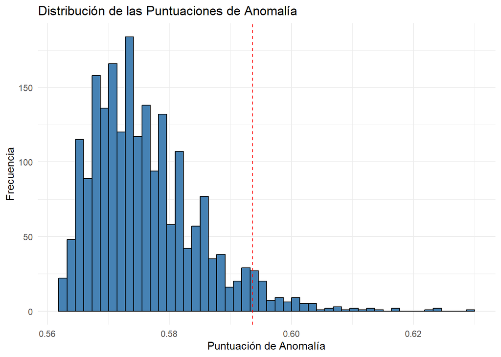

```r
# Distribución de las puntuaciones de anomalía
ggplot(df_anomaly, aes(x = anomaly_score)) +
  geom_histogram(bins = 50, fill = "steelblue", color = "black") +
  geom_vline(xintercept = threshold, color = "red", linetype = "dashed") +
  labs(title = "Distribución de las Puntuaciones de Anomalía",
       x = "Puntuación de Anomalía",
       y = "Frecuencia") +
  theme_minimal()
```

```r
# Total de anomalías detectadas
sum(df_anomaly$is_anomaly)
```

```
## [1] 92
```

```r
# Distribución de anomalías por Diagnosis
formattable(
  df_anomaly %>%
    group_by(Diagnosis, is_anomaly) %>%
    count()
)
```

| Diagnosis | is_anomaly | n |
| --- | --- | --- |
| 0 | FALSE | 748 |
| 0 | TRUE | 53 |
| 1 | FALSE | 1265 |
| 1 | TRUE | 39 |

```r
# Cruce entre outliers univariantes (BMI) y multivariantes
formattable(
  df_anomaly %>%
    group_by(outlier_BMI, is_anomaly) %>%
    count()
)
```

| outlier_BMI | is_anomaly | n |
| --- | --- | --- |
| NO | FALSE | 2013 |
| NO | TRUE | 92 |

```r
# Comparación de medianas entre observaciones anómalas y no anómalas
median_cluster_df <- df_anomaly %>%
  select(is_anomaly, all_of(vars_numericas)) %>%
  group_by(is_anomaly) %>%
  summarize(across(everything(), ~ median(.x, na.rm = TRUE)), .groups = "drop")

formattable(median_cluster_df)
```

| is_anomaly | Age | BMI | AlcoholConsumption | PhysicalActivity | DietQuality | SleepQuality | SystolicBP | DiastolicBP | CholesterolTotal | CholesterolLDL | CholesterolHDL | CholesterolTriglycerides | MoCA | FunctionalAssessment |
| --- | --- | --- | --- | --- | --- | --- | --- | --- | --- | --- | --- | --- | --- | --- |
| FALSE | 70 | 27.09612 | 10.00935 | 5.037150 | 4.838875 | 6.919847 | 132.0 | 90 | 228.0145 | 126.4354 | 59.50233 | 222.5230 | 14.99323 | 4.894692 |
| TRUE | 66 | 29.01985 | 11.74057 | 4.882069 | 4.526285 | 7.573401 | 153.5 | 95 | 243.5078 | 138.4638 | 53.12057 | 233.0416 | 14.52481 | 6.721304 |

```r
formattable(distinct_function_count(df_anomaly, "is_anomaly"))
```

| is_anomaly | n | percentage |
| --- | --- | --- |
| FALSE | 2013 | 95.629 |
| TRUE | 92 | 4.371 |

```r
# Eliminamos los registros identificados como anómalos y las columnas auxiliares
cols_auxiliares <- c("anomaly_score", "is_anomaly",
                     paste0("outlier_", vars_outlier_univariante))

df_wo_anomaly <- df_anomaly %>%
  filter(is_anomaly == FALSE) %>%
  select(-all_of(cols_auxiliares))

paste("Registros tras eliminar anomalías:", nrow(df_wo_anomaly))
```

```
## [1] "Registros tras eliminar anomalías: 2013"
```

Tras eliminar las observaciones anómalas, el dataset queda reducido al 95% de los registros originales, manteniendo los datos más representativos de la población objeto de estudio.

# 4. Balanceo de la muestra

## 4.1 Distribución inicial de `Diagnosis`

Antes de balancear, reviso el desbalanceo actual de la variable objetivo:

```r
formattable(distinct_function_count(df_wo_anomaly, "Diagnosis"))
```

| Diagnosis | n | percentage |
| --- | --- | --- |
| 1 | 1265 | 62.842 |
| 0 | 748 | 37.158 |

Se observa un desbalanceo claro: la clase positiva (Diagnosis = 1) es la mayoritaria, con un número de registros notablemente superior a la clase negativa (Diagnosis = 0). Este desbalanceo puede sesgar los modelos predictivos futuros hacia la clase mayoritaria, por lo que es necesario corregirlo antes de continuar.

## 4.2 Undersampling de la clase mayoritaria

Dado que el enuciado nos solicita reducir la clase mayoritaria hasta igualar el número de instancias de la clase minoritaria, se aplica **undersampling aleatorio**: se seleccionan aleatoriamente tantas observaciones de la clase mayoritaria como tiene la clase minoritaria, manteniendo todas las instancias de esta última:

```r
conteo <- table(df_wo_anomaly$Diagnosis)

clase_minoritaria <- names(conteo)[which.min(conteo)]
clase_mayoritaria <- names(conteo)[which.max(conteo)]
n_minoritaria     <- min(conteo)

paste("Clase minoritaria:", clase_minoritaria, "(", n_minoritaria, "registros )")
```

```
## [1] "Clase minoritaria: 0 ( 748 registros )"
```

```r
paste("Clase mayoritaria:", clase_mayoritaria, "(", max(conteo), "registros )")
```

```
## [1] "Clase mayoritaria: 1 ( 1265 registros )"
```

```r
df_minoritaria <- df_wo_anomaly %>% filter(Diagnosis == clase_minoritaria)
df_mayoritaria <- df_wo_anomaly %>% filter(Diagnosis == clase_mayoritaria)

# Muestreo aleatorio de la clase mayoritaria
df_mayoritaria_sample <- df_mayoritaria %>% slice_sample(n = n_minoritaria)

# Unión de los dos subconjuntos
df_equilibrio <- bind_rows(df_minoritaria, df_mayoritaria_sample)

paste("Registros tras undersampling:", nrow(df_equilibrio))
```

```
## [1] "Registros tras undersampling: 1496"
```

```r
formattable(distinct_function_count(df_equilibrio, "Diagnosis"))
```

| Diagnosis | n | percentage |
| --- | --- | --- |
| 0 | 748 | 50 |
| 1 | 748 | 50 |

La muestra está ahora perfectamente balanceada, con el mismo número de observaciones para cada clase de `Diagnosis`.